# Luu_compAssignment5

Hon Luu

5/28/2020

```r
library(ggplot2)
library(dplyr)
library(lessR)
```

##### 1.For the 2x2 table, determine the odds and the probabilities of texting while driving among males and females. Then compute the odds ratio of texting while driving that compares males to females. (5 points).

```r
prob_men <- 30/(30+10)
prob_women <- 34/((34+6))
OR_men <- prob_men/(1-prob_men)
OR_women <- prob_women/(1-prob_women)
OR_m.w <- OR_men/OR_women
```

```r
data <- read.csv("RELIGION.CSV",stringsAsFactors = TRUE)
data<-na.omit(data)
#data<-lapply(data, as.factor)
#data <-as.data.frame(data)
```

Basic EDA for a few variables: For the EDA, we’ll just do a few basic graphs and tabulation tables to understand the distribution of different types of people who attend religious school.

By RelSchool: not a lot attend religious school to begin with, so the data is very imbalanced.  
By Age: We see a difference in the mean age between those who attend religious school. The ones who attend range in the age of 35 to 40 while the ones who dont attend range between 35 to 60. The mean is also slightly different with the ones who dont attend religious school slightly higher.  
By education: the ranges and mean are very similar.  
By Income: People who do attend religious school have higher mean income.  
By Attend: Attend has a lot of outliers for the ones that attend religious school.  
By Marriage: more married people attend religious school than not married.  
By Race: Almost twice as many whites attend religious school than non-white.

```r
str(data)
```

```
## 'data.frame':    587 obs. of  10 variables:
##  $ ID      : int  2 3 4 5 6 7 10 13 15 17 ...
##  $ SEX     : int  1 1 1 1 1 0 1 1 1 1 ...
##  $ AGE     : int  30 32 51 18 37 18 70 57 72 46 ...
##  $ EDUC    : int  6 6 2 2 5 2 1 3 2 1 ...
##  $ INCOME  : int  11 6 11 3 6 3 1 4 2 1 ...
##  $ RELSCHOL: int  0 0 0 0 0 0 0 0 0 0 ...
##  $ MARRIED : int  1 1 1 0 1 0 0 1 1 0 ...
##  $ ATTEND  : int  6 5 2 6 6 5 5 6 5 3 ...
##  $ AGESQ   : int  900 1024 2601 324 1369 324 4900 3249 5184 2116 ...
##  $ RACE    : int  1 1 1 1 1 1 0 1 1 0 ...
##  - attr(*, "na.action")= 'omit' Named int [1:39] 7 38 48 51 56 59 62 74 75 83 ...
##   ..- attr(*, "names")= chr [1:39] "7" "38" "48" "51" ...
```

```
## [Violin/Box/Scatterplot graphics from Deepayan Sarkar's lattice package]
## >>> Suggestions
## Plot(AGE, out_cut=2, fences=TRUE, vbs_mean=TRUE)  # Label two outliers ...
## Plot(AGE, box_adj=TRUE)  # Adjust boxplot whiskers for asymmetry
## ttest(AGE ~ RELSCHOL)  # add the data parameter if not d
##
## AGE
##   - by levels of -
## RELSCHOL
##
##       n   miss     mean       sd      min      mdn      max
## 0   511      0    48.16    17.66    18.00    46.00    99.00
## 1    76      0    37.26     7.69    19.00    37.50    60.00
##
##
##        Max Dupli-
## Level   cations   Values
## ------------------------------
## 0          19     34
## 1           8     40
```

```
## Parameter  by  generally not meaningful for a single variable
## Too many points overlap, so parameter  by  converted to  by1
##   for a Trellis (facet) plot
```

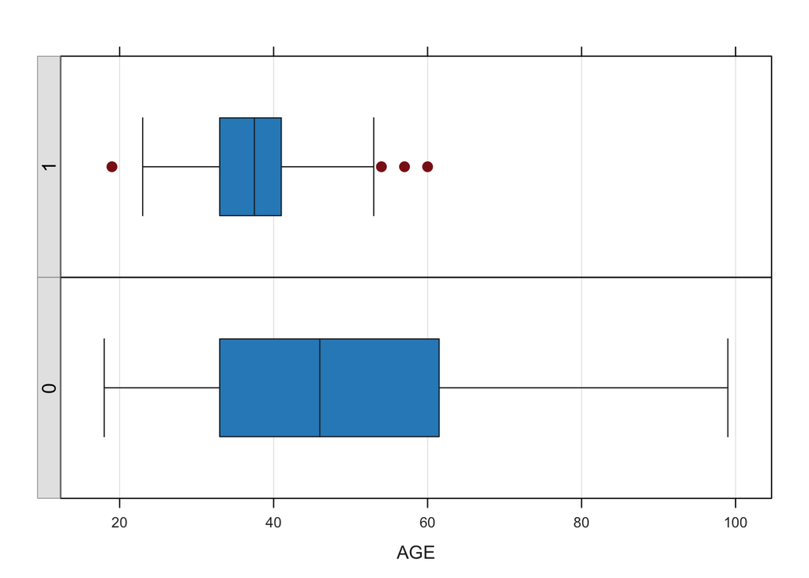

```r
BoxPlot(AGE, by=RELSCHOL, data=data)
```

```
## [Violin/Box/Scatterplot graphics from Deepayan Sarkar's lattice package]
## >>> Suggestions
## Plot(EDUC, out_cut=2, fences=TRUE, vbs_mean=TRUE)  # Label two outliers ...
## Plot(EDUC, box_adj=TRUE)  # Adjust boxplot whiskers for asymmetry
## ttest(EDUC ~ RELSCHOL)  # add the data parameter if not d
##
## Joint and Marginal Frequencies
## ------------------------------
##
##     EDUC
##         1   2   3   4   5   6 Sum
##   0    35 157 137  18 113  51 511
##   1     2  27  19   3  15  10  76
##   Sum  37 184 156  21 128  61 587
##
##
## Cramer's V: 0.075
##
## Chi-square Test:  Chisq = 3.283, df = 5, p-value = 0.656
## >>> Low cell expected frequencies, chi-squared approximation may not be accurate
##
##
##        Max Dupli-
## Level   cations   Values
## ------------------------------
## 0         157     2
## 1          27     2
```

```
## Parameter  by  generally not meaningful for a single variable
## Too many points overlap, so parameter  by  converted to  by1
##   for a Trellis (facet) plot
```

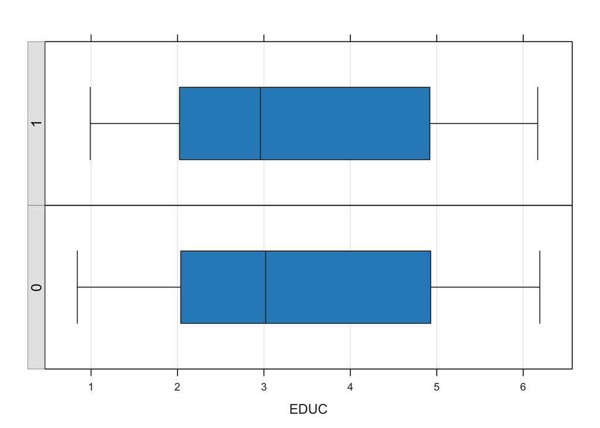

```r
BoxPlot(EDUC, by=RELSCHOL, data=data)
```

```
## [Violin/Box/Scatterplot graphics from Deepayan Sarkar's lattice package]
## >>> Suggestions
## Plot(INCOME, out_cut=2, fences=TRUE, vbs_mean=TRUE)  # Label two outliers ...
## Plot(INCOME, box_adj=TRUE)  # Adjust boxplot whiskers for asymmetry
## ttest(INCOME ~ RELSCHOL)  # add the data parameter if not d
##
## INCOME
##   - by levels of -
## RELSCHOL
##
##       n   miss     mean       sd      min      mdn      max
## 0   511      0     5.08     2.52     1.00     5.00    12.00
## 1    76      0     6.17     2.40     1.00     6.00    12.00
##
##
##        Max Dupli-
## Level   cations   Values
## ------------------------------
## 0         101     4
## 1          16     5
```

```
## Parameter  by  generally not meaningful for a single variable
## Too many points overlap, so parameter  by  converted to  by1
##   for a Trellis (facet) plot
```

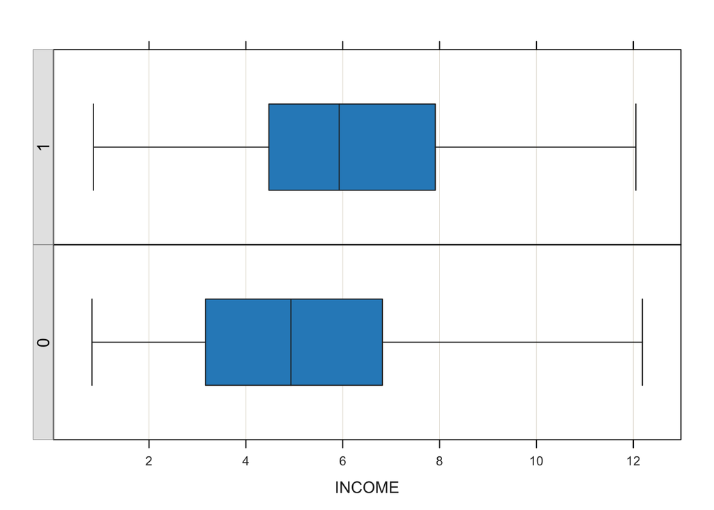

```r
BoxPlot(INCOME, by=RELSCHOL, data=data)
```

```
## [Violin/Box/Scatterplot graphics from Deepayan Sarkar's lattice package]
## >>> Suggestions
## Plot(ATTEND, out_cut=2, fences=TRUE, vbs_mean=TRUE)  # Label two outliers ...
## Plot(ATTEND, box_adj=TRUE)  # Adjust boxplot whiskers for asymmetry
## ttest(ATTEND ~ RELSCHOL)  # add the data parameter if not d
##
## Joint and Marginal Frequencies
## ------------------------------
##
##   ATTEND
##         1   2   3   4   5   6 Sum
##   0     5  41  47 100 239  79 511
##   1     0   3   4   9  50  10  76
##   Sum   5  44  51 109 289  89 587
##
##
## Cramer's V: 0.134
##
## Chi-square Test:  Chisq = 10.608, df = 5, p-value = 0.060
## >>> Low cell expected frequencies, chi-squared approximation may not be accurate
##
##
##        Max Dupli-
## Level   cations   Values
## ------------------------------
## 0         239     5
## 1          50     5
```

```
## Parameter  by  generally not meaningful for a single variable
## Too many points overlap, so parameter  by  converted to  by1
##   for a Trellis (facet) plot
```

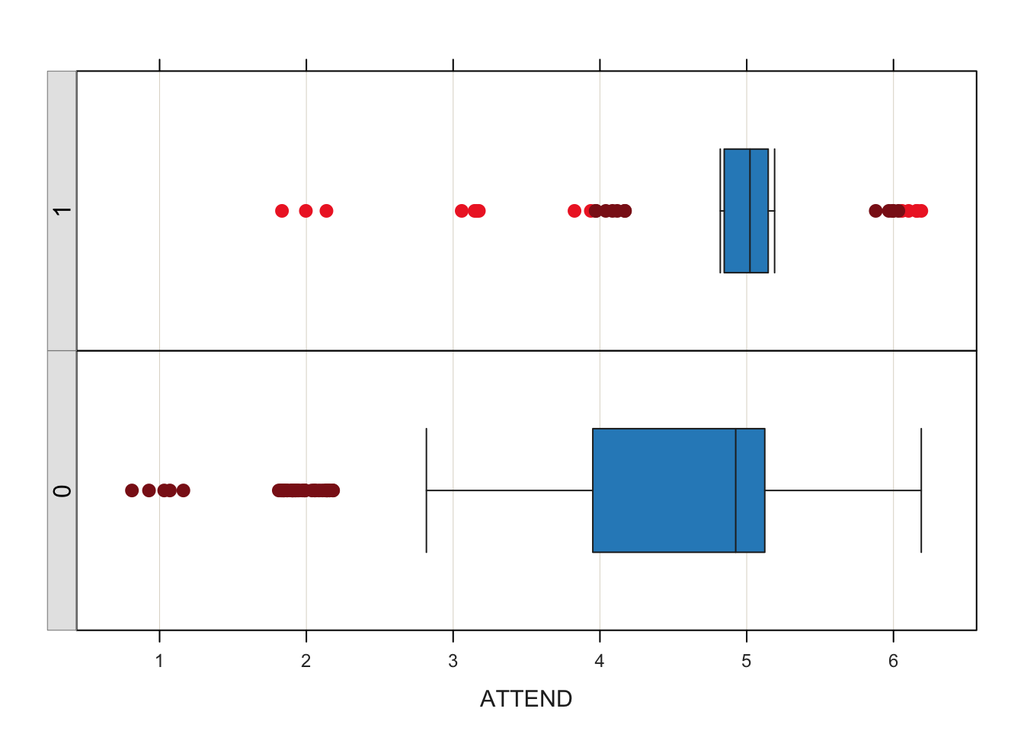

```r
BoxPlot(ATTEND, by=RELSCHOL, data=data)
```

```
## [Violin/Box/Scatterplot graphics from Deepayan Sarkar's lattice package]
## >>> Suggestions
## Plot(MARRIED, out_cut=2, fences=TRUE, vbs_mean=TRUE)  # Label two outliers ...
## Plot(MARRIED, box_adj=TRUE)  # Adjust boxplot whiskers for asymmetry
## ttest(MARRIED ~ RELSCHOL)  # add the data parameter if not d
##
## Joint and Marginal Frequencies
## ------------------------------
##
##  MARRIED
##         0   1 Sum
##   0   194 317 511
##   1    18  58  76
##   Sum 212 375 587
##
##
## Cramer's V (phi): 0.100
##
## Chi-square Test:  Chisq = 5.848, df = 1, p-value = 0.016
##
##
##        Max Dupli-
## Level   cations   Values
## ------------------------------
## 0         317
## 1          58
```

```
## Parameter  by  generally not meaningful for a single variable
## Too many points overlap, so parameter  by  converted to  by1
##   for a Trellis (facet) plot
```

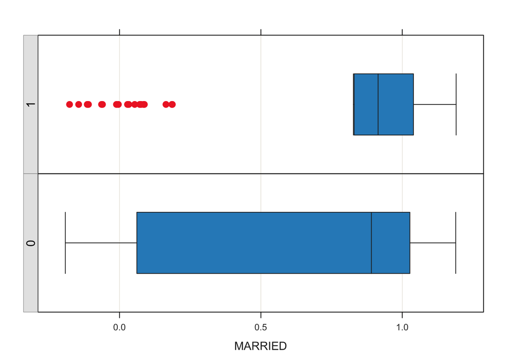

```r
BoxPlot(MARRIED, by = RELSCHOL, data=data)
```

```r
table(data$RELSCHOL)
```

```
##
##   0   1
## 511  76
```

```r
xtabs(~RELSCHOL+MARRIED, data=data)
```

```
##         MARRIED
## RELSCHOL   0   1
##        0 194 317
##        1  18  58
```

```r
xtabs(~RELSCHOL+RACE, data=data)
```

```
##         RACE
## RELSCHOL   0   1
##        0  74 437
##        1  25  51
```

##### 2a Compute the overall odds and probability of attending a religious school, assuming this data is from a random sample.

```r
xtabs(~RELSCHOL, data=data)
```

```
## RELSCHOL
##   0   1
## 511  76
```

```r
xtabs(~RELSCHOL+RACE, data=data)
```

```
##         RACE
## RELSCHOL   0   1
##        0  74 437
##        1  25  51
```

```r
P_relschool <- 80/(80+546)
P_notrelschool <- 1-P_relschool
OR <- P_relschool/P_notrelschool
```

##### 2b Cross-tabulate RELSCHOL with RACE (coded: 0=non-white, 1=white). What are the probabilities that non-white students and white students attend religious schools? What are the odds that white students and non-white students attend religious schools? What is the odds ratio that compares white and non-white students?

```r
Race_School<-xtabs(~RELSCHOL+RACE, data=data)
(addmargins(Race_School))
```

```
##         RACE
## RELSCHOL   0   1 Sum
##      0    74 437 511
##      1    25  51  76
##      Sum  99 488 587
```

```r
p_nonwhite <- 26/(102)
odds_nonwhite <-p_nonwhite/(1-p_nonwhite)
p_white <- 54/(524)
odds_white <- p_white/(1-p_white)
race_OR <- odds_white/odds_nonwhite
```

##### 2c Plot RELSCHOL (Y) by INCOME as a scatterplot. The INCOME variable is actually an ordinal variable that is associated with income brackets. This is an old dataset, so for example, INCOME=4  $20,000-$29,999. Is there a value of INCOME that seems to separate or discriminate between those attending religious schools and those that don’t? Create a variable that dichotomizes INCOME based on this value you observed. Call this new variable D_INCOME. Cross-tabulate RELSCHOL with D_INCOME. What are the probabilities that low income students and higher students attend religious schools? What are the odds that lower income students and higher income students attend religious schools? What is the odds ratio that compares lower and higher income students?

The scatter plot doesn’t appear to give a definite answer as to which income level discriminates between religious school and non religious school. In all income brackets, non-religious school attendance is more prominant.  
Looking at the crosstabulation table and focusing on column proportion though, we do see the higher proportion changes from income bracket 2 to 3. Assuming there is not any credibility issues with low volume, since we see the big jump in proportion between income 2 to 3, I would say that 3 is the discriminating point.

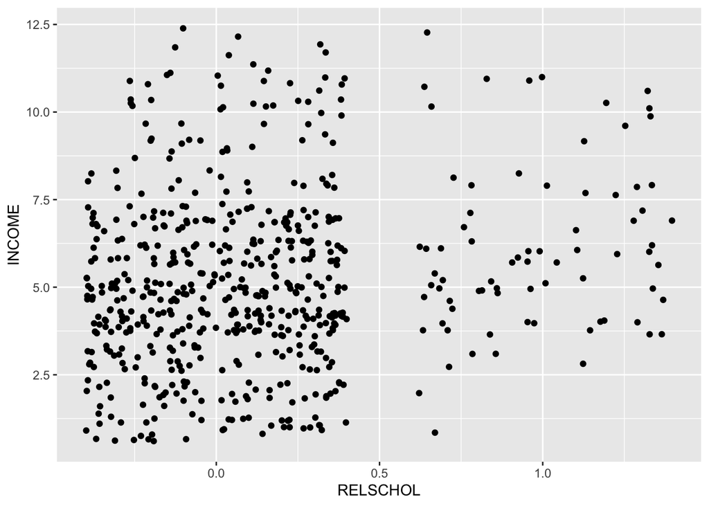

```r
print(ggplot(data=data, aes(x=RELSCHOL, y=INCOME)) + geom_jitter())
```

```r
tabs<-xtabs(~RELSCHOL+INCOME, data=data)

(round(prop.table(tabs,2),2))
```

```
##         INCOME
## RELSCHOL    1    2    3    4    5    6    7    8    9   10   11   12
##        0 0.97 0.98 0.92 0.89 0.84 0.82 0.91 0.71 0.94 0.78 0.74 0.86
##        1 0.03 0.02 0.08 0.11 0.16 0.18 0.09 0.29 0.06 0.22 0.26 0.14
```

```r
data$D_Income <- ifelse(as.numeric(data$INCOME)>=3,1,0)
tabs<-xtabs(~RELSCHOL+D_Income, data=data)
addmargins(tabs)
```

```
##         D_Income
## RELSCHOL   0   1 Sum
##      0    81 430 511
##      1     2  74  76
##      Sum  83 504 587
```

```r
p_low <- 2/84
p_high <- 74/506
OR_low <- p_low/(1-p_low)
OR_high <- p_high/(1-p_high)
lowhigh <- OR_low/OR_high
```

##### 2d Plot RELSCHOL (Y) by ATTEND as a scatterplot. The ATTEND variable is the number of times the survey respondent attends a service during a month. Cross-tabulate RELSCHOL with ATTEND. Are the proportion profiles the same for those attending religious school versus not, across the values of the ATTEND variable? Is there a value of ATTEND that seems to separate or discriminate between those attending religious schools and those that don’t? Save this value for later.

The proportions are not the same across the attend profiles. With attendence, we see the bigist drop at 5 attendance. so 5 may be a discriminating point.

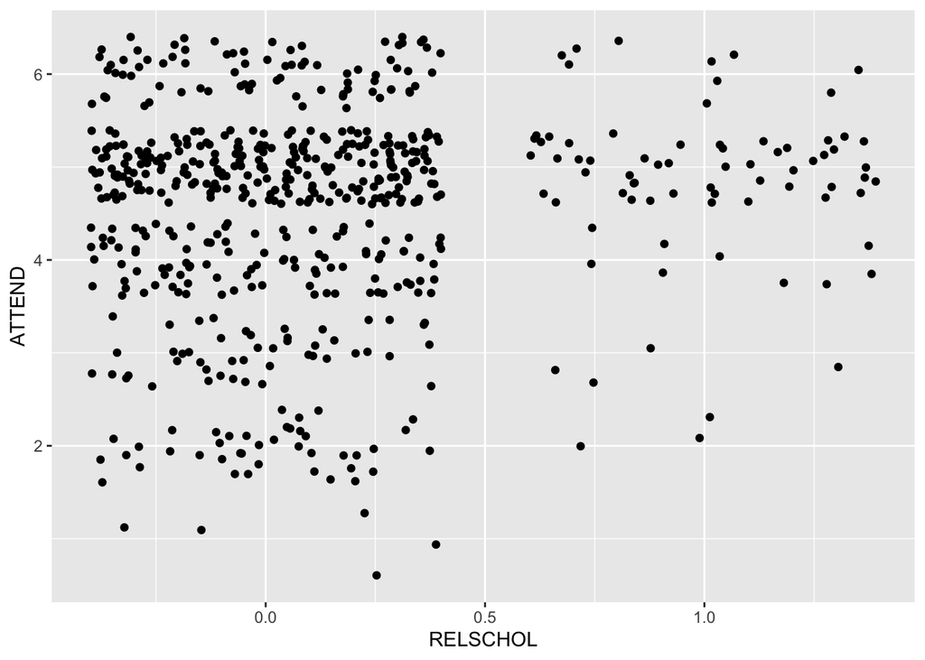

```r
ggplot(data=data, aes(x=RELSCHOL, y=ATTEND)) + geom_jitter()
```

```r
tabs<-xtabs(~RELSCHOL+ATTEND, data=data)

round(prop.table(tabs,2),2)
```

```
##         ATTEND
## RELSCHOL    1    2    3    4    5    6
##        0 1.00 0.93 0.92 0.92 0.83 0.89
##        1 0.00 0.07 0.08 0.08 0.17 0.11
```

##### 3. First, fit a logistic model to predict RELSCHOL (Y) using only the RACE (X) variable. Call this Model 1. Report the logistic regression model and interpret the parameter estimates for Model 1. Report the AIC and BIC values for Model 1. (3 points).

```r
model1 <- glm(RELSCHOL~RACE, family="binomial", data=data)
summary(model1)
```

```
##
## Call:
## glm(formula = RELSCHOL ~ RACE, family = "binomial", data = data)
##
## Deviance Residuals:
##     Min       1Q   Median       3Q      Max
## -0.7630  -0.4699  -0.4699  -0.4699   2.1253
##
## Coefficients:
##             Estimate Std. Error z value   Pr(>|z|)
## (Intercept)  -1.0852     0.2313  -4.691 0.00000272
## RACE         -1.0629     0.2746  -3.871   0.000109
##
## (Dispersion parameter for binomial family taken to be 1)
##
##     Null deviance: 452.44  on 586  degrees of freedom
## Residual deviance: 438.73  on 585  degrees of freedom
## AIC: 442.73
##
## Number of Fisher Scoring iterations: 4
```

```r
m1OR <- (exp(-1.0911)-1)*100

m1AIC<-AIC(model1)
m1BIC<-BIC(model1)
m1AIC
```

```
## [1] 442.7283
```

```r
m1BIC
```

```
## [1] 451.4784
```

The AIC is 442.7283144.  
The BIC is 451.478364.

##### 4. Next, fit a logistic model to predict RELSCHOL (Y) using only the INCOME(X) variable. Call this Model 2. For Model 2, do the following: (6 points).

##### Report the logistic regression model and interpret the parameter estimates for Model 2. Report the AIC and BIC values for Model 2. How do these compare to Model 1?

```r
data$INCOME <- as.factor(data$INCOME)
model2 <- glm(RELSCHOL~INCOME, family="binomial", data=data)
summary(model2)
```

```
##
## Call:
## glm(formula = RELSCHOL ~ INCOME, family = "binomial", data = data)
##
## Deviance Residuals:
##     Min       1Q   Median       3Q      Max
## -0.8203  -0.5971  -0.4921  -0.2309   2.7592
##
## Coefficients:
##             Estimate Std. Error z value Pr(>|z|)
## (Intercept)  -3.6109     1.0134  -3.563 0.000366
## INCOME2      -0.1733     1.4317  -0.121 0.903669
## INCOME3       1.1054     1.1390   0.970 0.331819
## INCOME4       1.5607     1.0554   1.479 0.139183
## INCOME5       1.9768     1.0496   1.883 0.059656
## INCOME6       2.1143     1.0529   2.008 0.044639
## INCOME7       1.3422     1.1004   1.220 0.222560
## INCOME8       2.6946     1.0964   2.458 0.013980
## INCOME9       0.9029     1.4470   0.624 0.532642
## INCOME10      2.3300     1.1325   2.057 0.039651
## INCOME11      2.5813     1.1395   2.265 0.023494
## INCOME12      1.8192     1.4811   1.228 0.219356
##
## (Dispersion parameter for binomial family taken to be 1)
##
##     Null deviance: 452.44  on 586  degrees of freedom
## Residual deviance: 425.91  on 575  degrees of freedom
## AIC: 449.91
##
## Number of Fisher Scoring iterations: 6
```

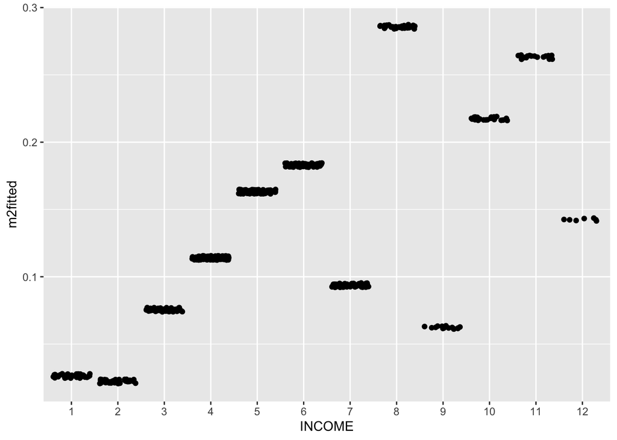

```r
m2AIC<-AIC(model2)
m2BIC<-BIC(model2)

data$m2fitted <- model2$fitted.values
ggplot(data=data, aes(x=INCOME, y=m2fitted)) + geom_jitter()
```

The AIC is 449.9087045.  
The BIC is 502.4090024.

##### Use the logit predictive equation for Model 2 to compute PI for each record. Plot PI (Y) by INCOME(X). At what value of X, does the value of PI exceed 0.50? How does this value compare to your visual estimate from problem 2c)?

The equation to calculate the probability would be to utilize each coefficient in the summary output.  
The equation would be $Y=-3.6109 + \beta_i*Income$ where $\beta$ would be the coefficient of whichever income bracket the observation falls into. In our case, after we get our $Y$, we would $e^Y$ that value to get to the odds ratio. we would then convert it back to probability by $\frac{e^y}{1+e^y}$.

For this exercise, the model output has fitted values so we dont have to manually calculate it.

The plot appears to confirm that none of the probaiblities ever reach 50%. Overall, the model seems to tell me that potentially,the discriminating point is at income bracket = 8, versus my original thought of 3.

##### 5. Next, fit a logistic model to predict RELSCHOL (Y) using only the ATTEND(X) variable. Call this Model 3. For Model 3, do the following: (6 points).

#####Report the logistic regression model and interpret the parameter estimates for Model 3. Report the AIC and BIC values for Model 3. How do these compare to Models 1 and 2?

```r
data$ATTEND <- as.factor(data$ATTEND)
model3 <- glm(RELSCHOL~(ATTEND), family="binomial", data=data)
summary(model3)
```

```
##
## Call:
## glm(formula = RELSCHOL ~ (ATTEND), family = "binomial", data = data)
##
## Deviance Residuals:
##     Min       1Q   Median       3Q      Max
## -0.6164  -0.6164  -0.4882  -0.4042   2.3176
##
## Coefficients:
##             Estimate Std. Error z value Pr(>|z|)
## (Intercept)   -15.57     650.87  -0.024    0.981
## ATTEND2        12.95     650.87   0.020    0.984
## ATTEND3        13.10     650.87   0.020    0.984
## ATTEND4        13.16     650.87   0.020    0.984
## ATTEND5        14.00     650.87   0.022    0.983
## ATTEND6        13.50     650.87   0.021    0.983
##
## (Dispersion parameter for binomial family taken to be 1)
##
##     Null deviance: 452.44  on 586  degrees of freedom
## Residual deviance: 440.87  on 581  degrees of freedom
## AIC: 452.87
##
## Number of Fisher Scoring iterations: 14
```

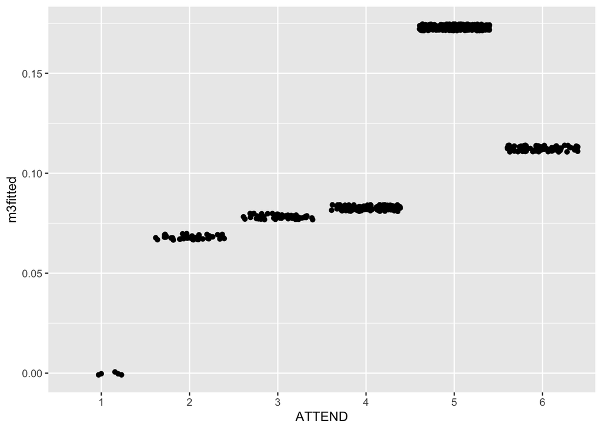

```r
m3AIC<-AIC(model3)
m3BIC<-BIC(model3)

data$m3fitted <- model3$fitted.values


ggplot(data=data, aes(x=ATTEND, y=m3fitted)) + geom_jitter()
```

The AIC is 452.8714088.  
The BIC is 479.1215577.

Looking at the output summary, the higher the attendance the higher the coefficient (which translates to higher probability of attending religious school). We get a slight increase at attendance = 5, but then it dips backs down. Again, the values are not significant though.